# Cheap trick for label spacing

### Spacing around text and labels

Sometimes you might find that a label gets too close to something else.

Below are versions of the plot-in-plot survival curves where the exposure group labels are placed differently in the risk table using different values of `hjust`.

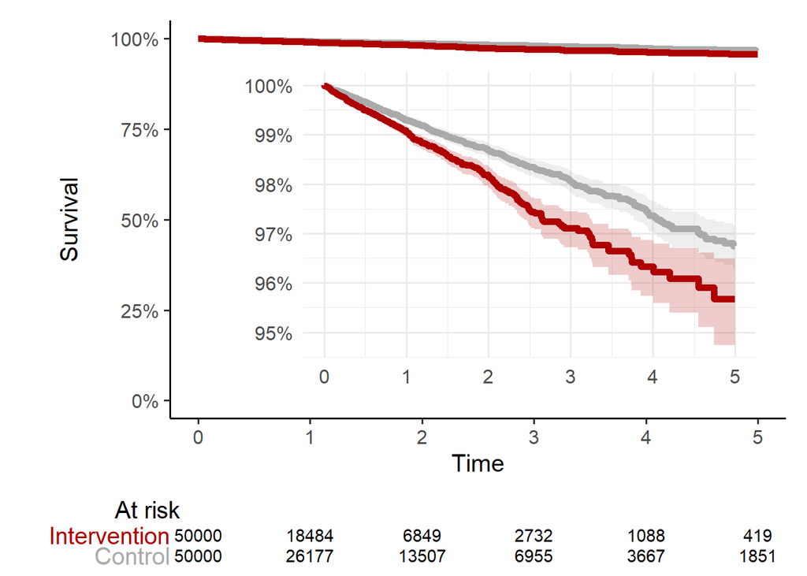

Figure 1: Right-aligned labels (`hjust = 1`)

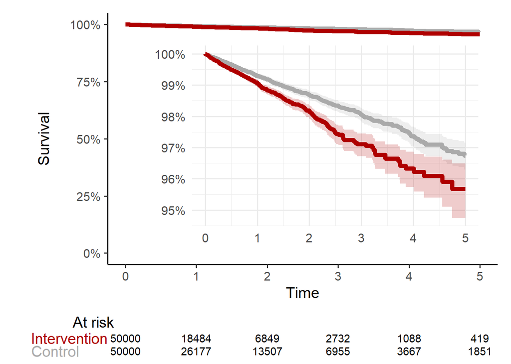

Figure 2: Left-aligned labels (`hjust = 0`)

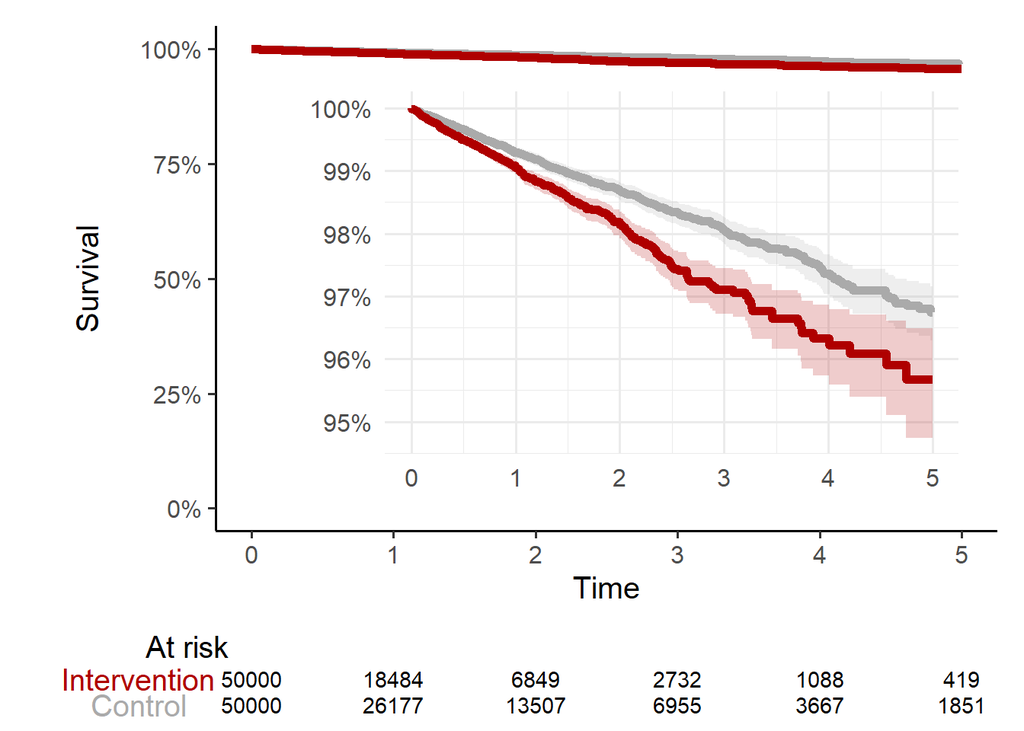

Figure 3: Center-aligned labels (`hjust = .5`)

Figure 1 with right aligned labels corresponds to the one you have made already. Here the labels might be a tad too close to the numbers in the risk table. One solution could be to left align the labels as in Figure 2. However, the difference in distance between labels and numbers might be less aesthetically pleasing, and “Intervention” is still close to the text. Figure 3 is just plain ugly. One cheap trick that is often worth remembering is to edit the labels of the data. I.e., if the labels had been specified as here

```r
survival <- fread("//uni.au.dk/dfs/HE_KEA-DCESAS02/S/Stat day May 2025/risk_curves/data/riskdata.csv") |>
  mutate(x = factor(
    x,
    levels = c(2,1),
    # note the space after the labels
    labels = c("Control ", "Intervention ")
  )) |>
  filter(analysis == "Survival")
```

then there is daylight between the labels and the numbers at risk as seen in Figure 4

**Cheap trick**

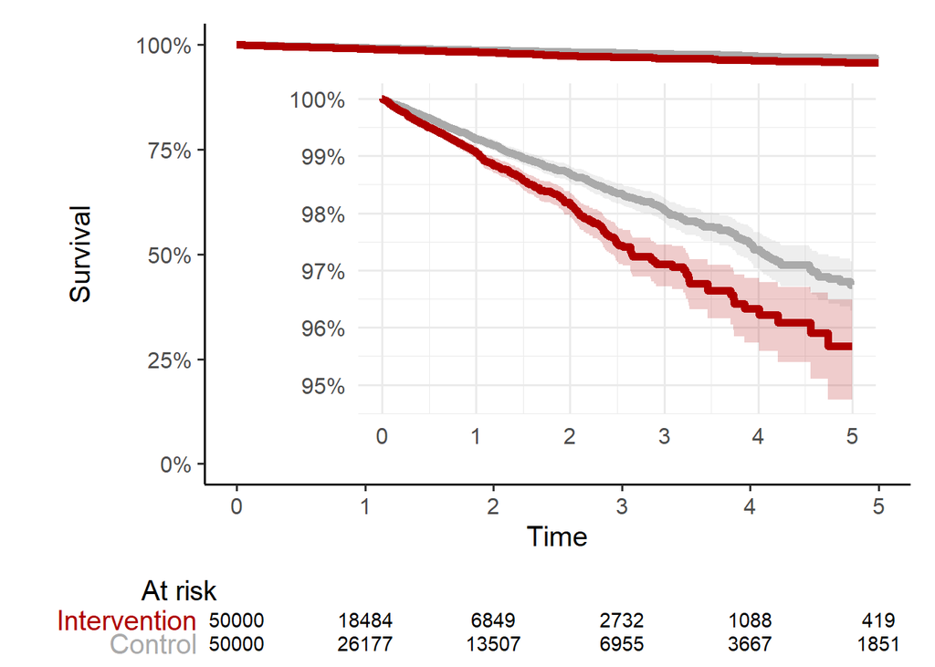

Figure 4: Right-aligned labels (`hjust = 1`) with additional space in label

A similar trick can be useful if you need to add space to the left. Suppose you have some time-trend data where there are too many groups to make a good palette, and you decide to remove the legend and instead insert the labels as text to the right of the figures where the individual lines end:

```r
library(ggplot2)

# Some nonsensical data on time trends of something for various animals

# First a table with an observation for each animal in each year
set.seed(13)
grid <- expand.grid(
  Time = 2020:2025,
  group = c(
    "Cattle",
    "Chickens",
    "Pigs",
    "Turkeys",
    "Horses",
    "Drop bears",
    "Foxes",
    "Guinea pigs",
    "Herrings"
  )
)

# A continuous outcome variable with random values
grid$y <- runif(nrow(grid), 0, 10)

# New group variable, constructed by adding some space before the text in the grouping variable
grid$new_group <- paste(" ",grid$group)

# Last observation per group (used to insert the text on the right of the lines)
anno <- subset(grid, Time == 2025)

# The plot where no space is included between lines and text.
# Substitute group for new_group to get spacing.
ggplot(grid, aes(x = Time, y = y, color = group)) +
  theme_classic() +
  theme(legend.position = "none",
        # expanding margins to the right to make room for the labels
        plot.margin = margin(t = 0,
                             r = 2,
                             b = 0,
                             l = 0,
                             unit = "cm")) +
  # setting clip = "off" means the text in the margin will not be cut
  coord_cartesian(clip = "off") +
  geom_line(linewidth = 1.5) +
  geom_text(data = anno,
            aes(label = group),
            hjust = 0)
```

**Labels too close to lines using the variable `group`**

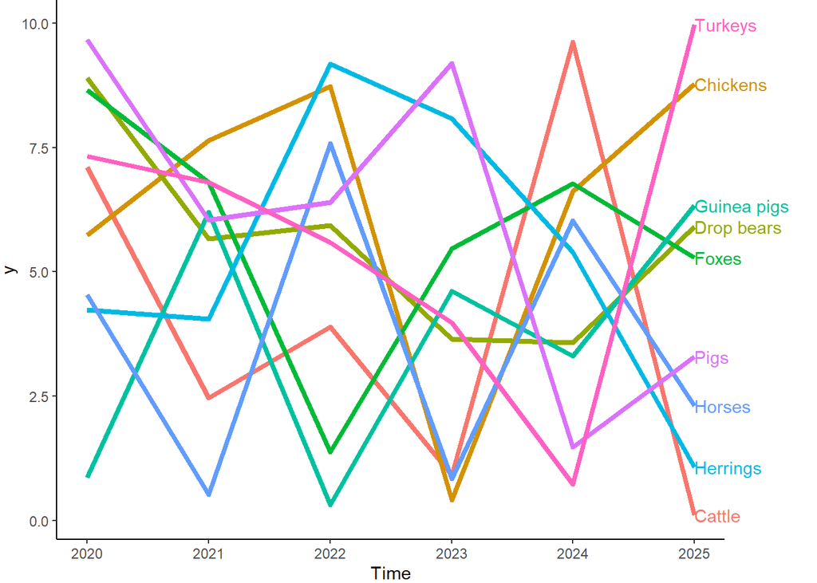

**Labels positioned better using the variable `new_group`**

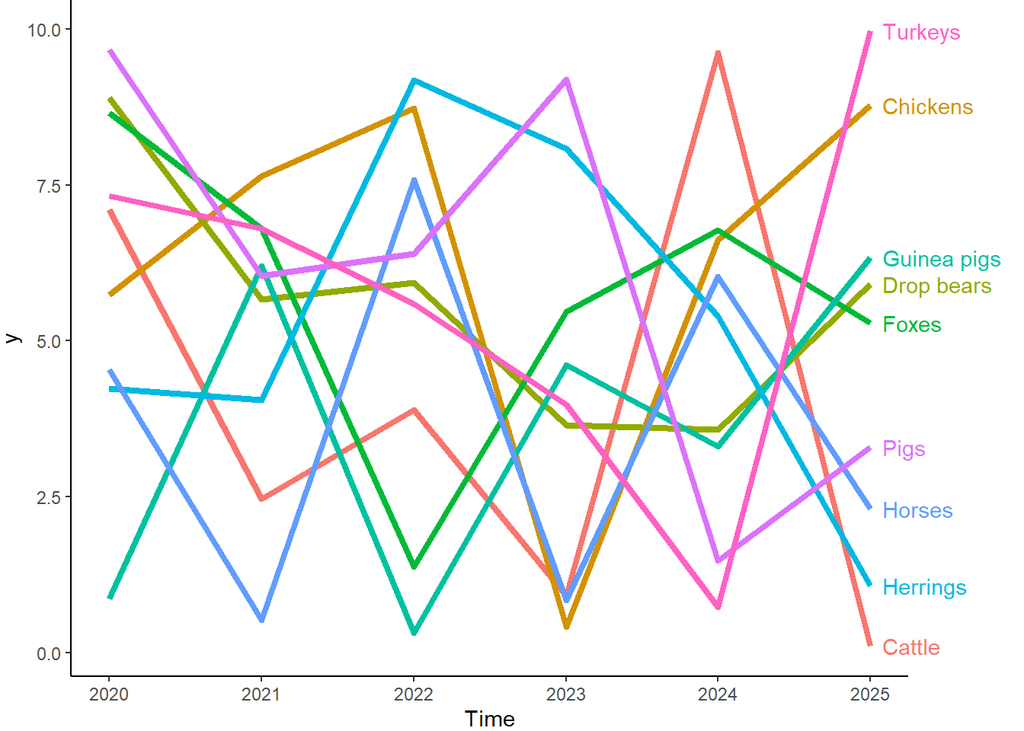